# R para Cientistas Sociales: Taller Introductorio

💻*¡Bienvenidos al Taller introductorio: R para Cientistas Sociales!* 💻.

A a lo largo de esta jornada abordaremos el uso de R para las ciencias sociales. **No se requiere experiencia previa en programación ni análisis de datos,** ya que este taller está diseñado para todxs, desde principiantes hasta aquellos con cierta experiencia.

🤔 **¿Por qué R?** R es un lenguaje de programación ampliamente utilizado en la ciencia de datos, estadísticas y análisis de datos. En las ciencias sociales, R puede ser una herramienta invaluable para explorar datos, identificar patrones, y comunicar tus hallazgos de manera efectiva estudies la carrera que estudies.

**Podes acceder al repositorio [acá](https://github.com/ariibard/R-para-Ciencias-Sociales)**. Allí vamos a estar subiendo los archivos y documentos del curso.

➡️ Este taller es organizado por el proyecto de investigación *“La trama territorial de programas sociales en el conurbano bonaerense: entre nación, municipios y organizaciones sociales (2015-2023)” r*adicado en el Departamento de Derecho y Ciencia Política de la **Universidad Nacional de La Matanza** (UNLaM).

## Instalación de R y RStudio

#### Instalación de R

1️⃣ Para descargar R y Rstudio, debes acceder a la página de intalación de [Posit](https://posit.co/download/rstudio-desktop/).

[figure not shown]

2️⃣ Lo primero que debemos hacer es **instalar R**. Para ello, seleccionaremos el **paso 1** que te llevara a la [página de CRAN](https://cran.rstudio.com/) (Comprehensive R Archive Network) que es el *repositorio central de software de R*. Allí, deberás seleccionar el *sistema operativo que utilices*.

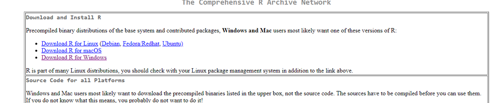

3️⃣ Luego deberás seleccionar el “install for the first time” (Instalar por primera vez) en la parte superior de la página:

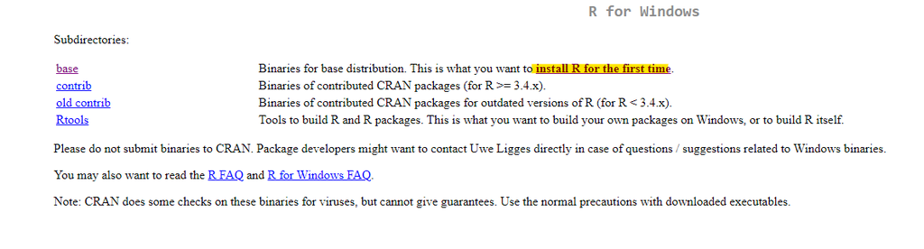

#### Instalación de R Studio

5️⃣En cuanto hayas descargado R, deberás descargar RStudio que es el IDE que estaremos usando a lo largo del curso.

Para ello vuelve a la [página de posit](https://posit.co/download/rstudio-desktop/) y selecciona el Paso 2.

[figure not shown]

También podés seleccionar la opción de descarga que mejor se adapte a tu sistema operativo

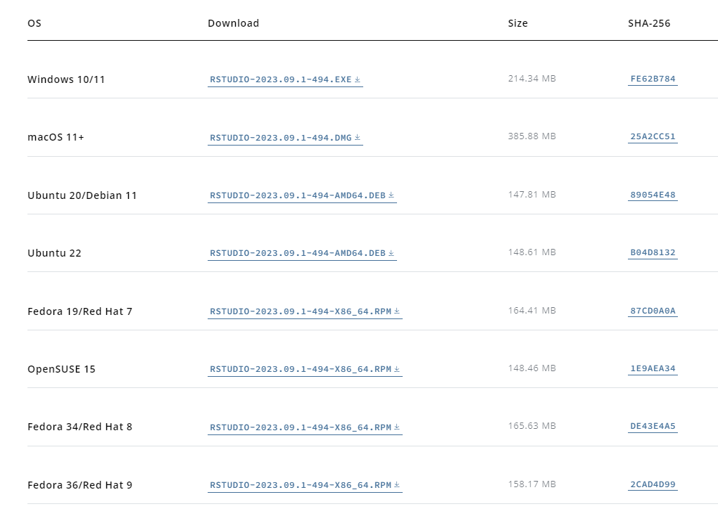

¡Felicidades! Ahora tienes R y RStudio instalados en tu compu. En caso de tener algún inconveniente no dudes en escribirnos.

📅 **Nos vemos el 23 de noviembre a las 17 30 hs en la biblioteca de la UNLaM para continuar con este taller**

✨ En esta página estaremos subiendo lo que veremos ese día ✨

[figure not shown]